# Heritage Speaker’s English Vowels

Andrea Alcaraz,Daniel Dorado

December 14, 2017

## Introduction

The objective of this data analysis was to observe the vowels spoken by an English/Spanish bilingual. The vowel, time, F1, F2, F3, duration and the word in which the vowel appeared was documented. Praat was used to take these measurements. Speaker 1 will refer to Andrea’s speaker and Speaker 2 will refer to Daniel’s speaker.

## Formant Plots

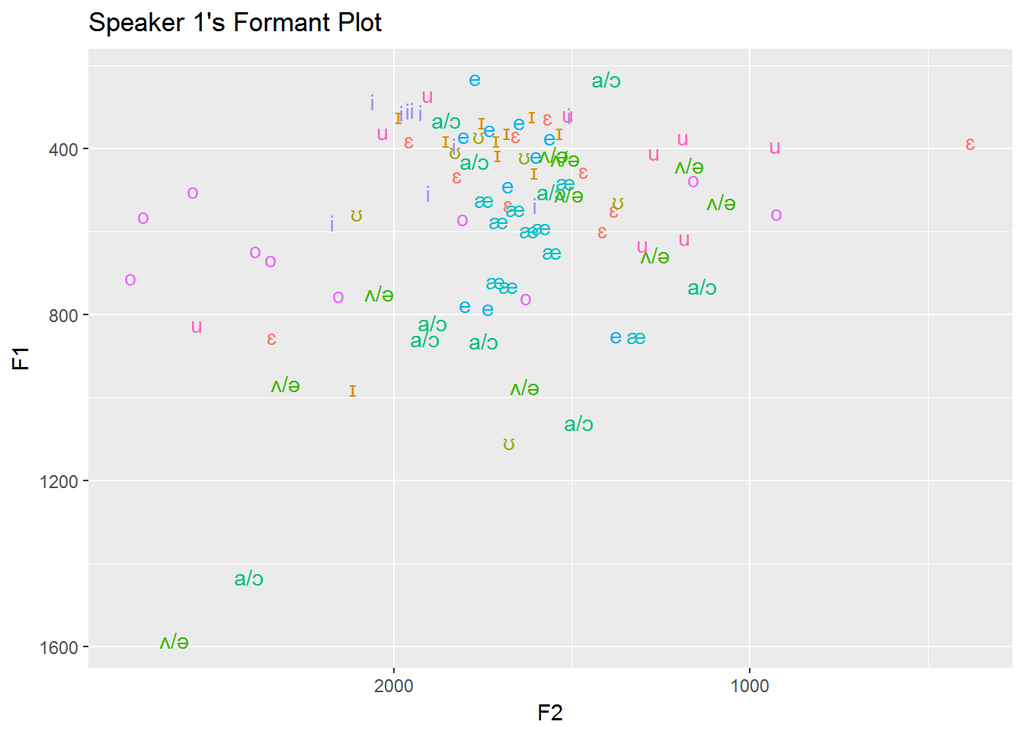

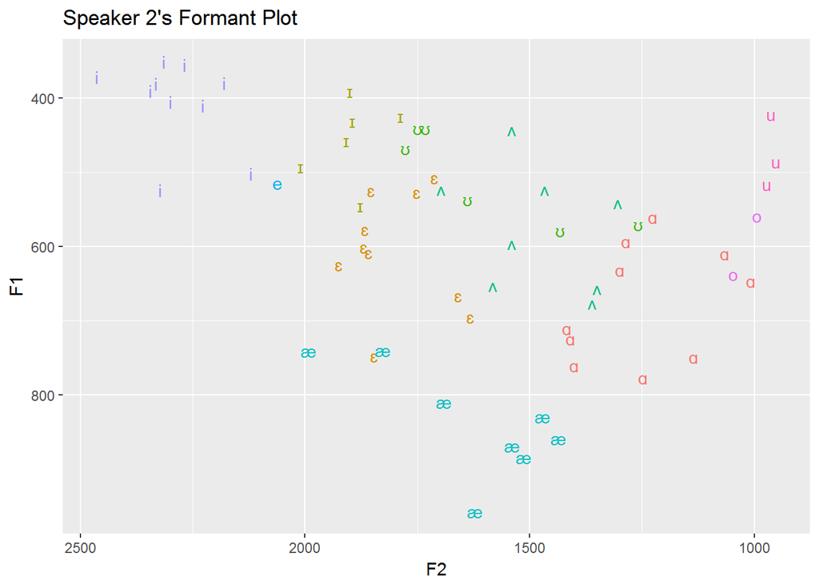

## Vowel Hulls

To help visualize the individual vowel groupings a little better, we find the convex hulls, (the extreme points of each vowel) and plot that over the vowels so that we can see the *boundaries* of each vowel.

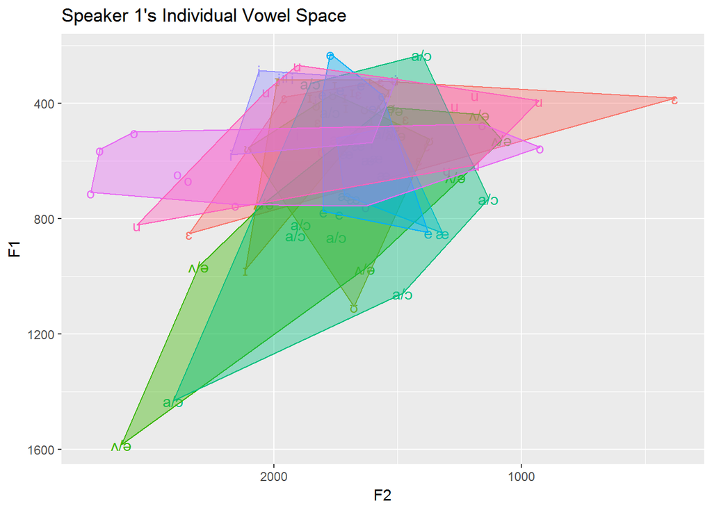

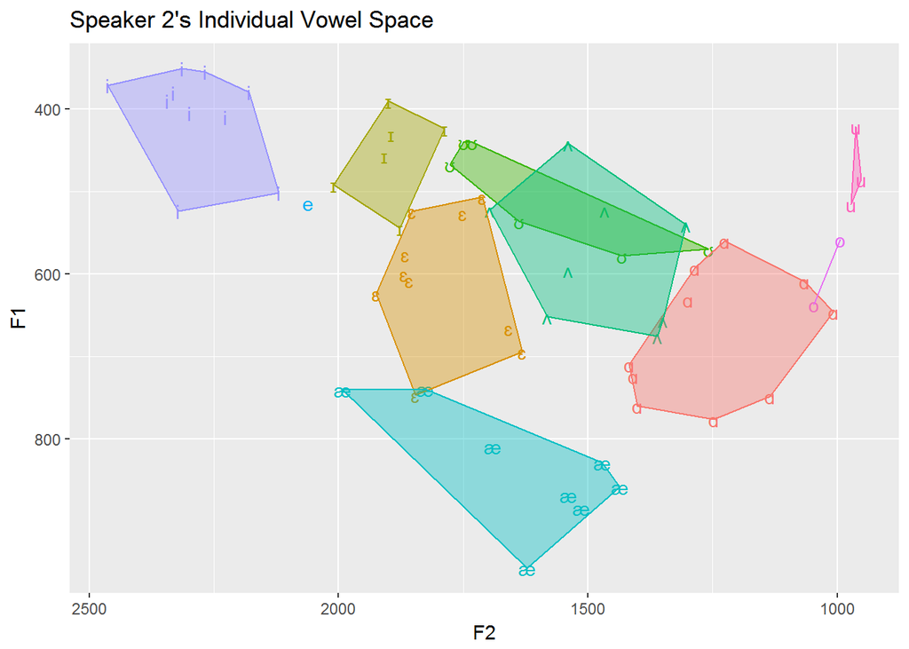

## Speakers’ Entire Vowel Space

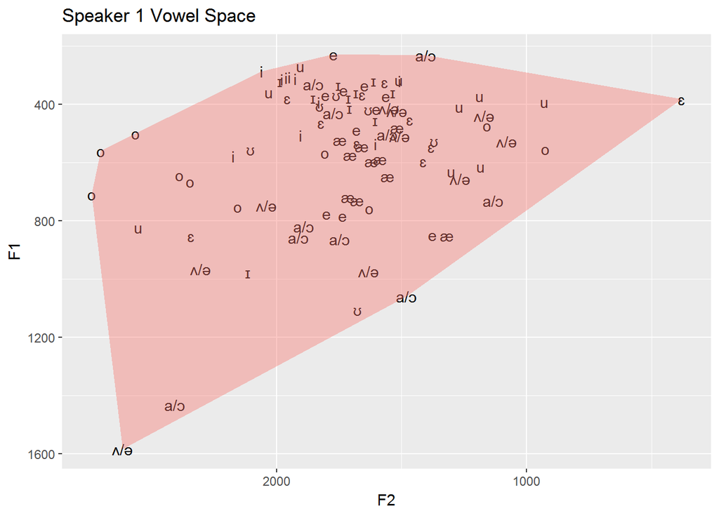

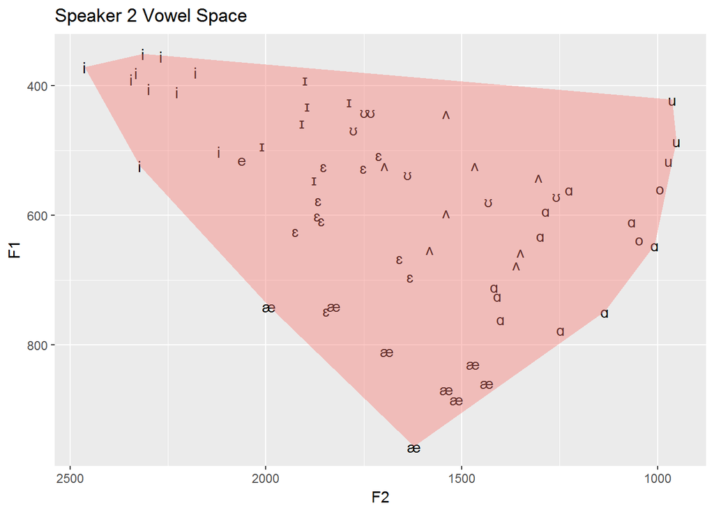

## Vowel Means

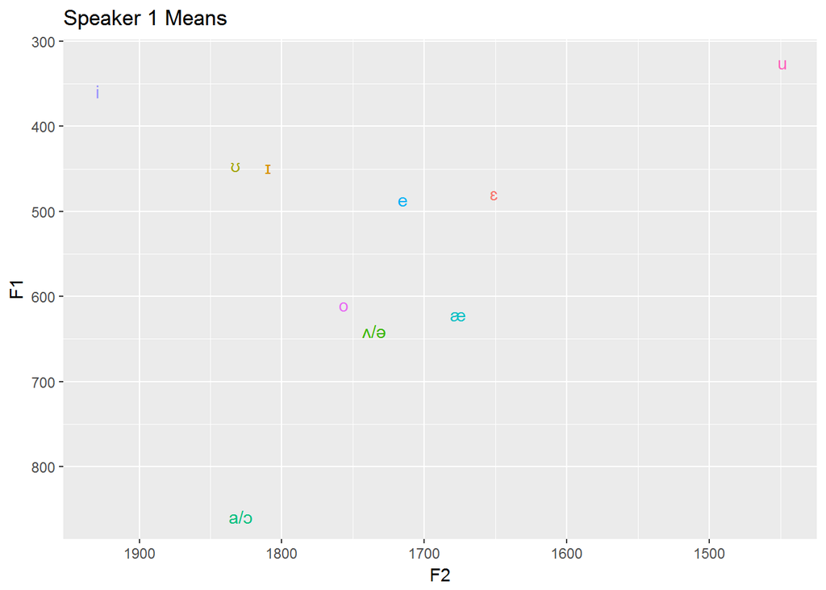

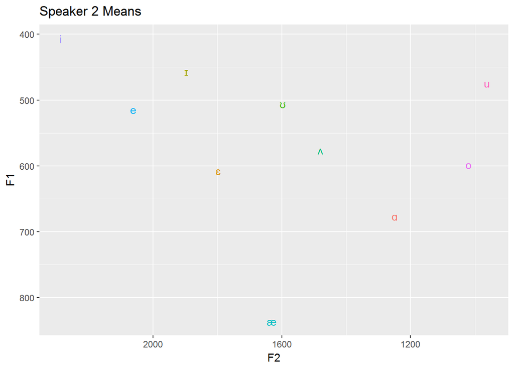

## Conclusion

**Andrea Side Notes**

There were a few complications that emerged both in the processes of collecting the data and after plotting the results. While collecting the data, there were instances in where a vowel would not be consistent. There would instances in which a vowel would sound one way and another instance in where it would sound more like another. This made documenting the vowel difficult; as it would pose a challenge as to how to treat the vowel as and where to list it under. Another reason this may have occurred in addition to the former was also do to the instances in which a vowel was part of a diphthong. As a result, the issue of disrupted frequencies became a possibility and was evident in plotting the data into a graph. When plotting the F1 and F2 frequencies, the scatter plot did not appear in the shape of what would seem like an IPA vowel chart. Instead, it showed vowels scattered all over in areas that they should have not been. For example, [i] would appear in the same areas as [u] would appear in. In order to weed out the data from these issues, the vowels that occurred in diphthongs was removed from the data set. The data slightly improved after the removal of the diphthongs, however there were still discrepancies evident in the plot. In attempts to enhance the plot, the means of the vowels’ F1 and F2 frequencies were taken in order to receive an average of those values and then plot them in order to see if the data improved. After plotting these values, the result of the scatter plot was much better; the scatter plot looked more like an IPA vowel chart. Nevertheless, some values were still a little unusual, such as the placement of [o] in the plot. [o] was more fronted. A possible conclusion that may be made from this is that being a bilingual speaker has an impact of how one may produce sounds; although this may not suffice as an explanation as to how off the discrepancies are. If this project was to be continued, it would be best to go through the entire audio and collect the data once more. This revision would have been beneficial to do for this project, however, for the sake of this project, this process would not have been adequate due to the limited time frame available to complete this.

**Daniel Side Notes**

One of the things I found interesting, was just how many factors are interplaying when it comes to measuring vowels accurately. Stressed and nonstressed, where the speaker wants to put the emphasis, the surrounding consonants especially the liquids, authentic vs read speech or elicited speech, etc. There were only a few cases where I felt that yes vowel was unstressed, but the speaker had reduced it to schwa, so while in theory it was, for example an [a], in reality it was a schwa. So not only did we have to rely on the citation form, but our own abilities to determine whether or not it was the correct vowel we were measuring. By expecting a certain vowel to in a word, I had missed the vowel that was actually there. A better approach might be to just collect all the vowel and not label them, and perform a cluster analysis to group simular vowels together. This would enable us to more easily see which vowels a speaker was actually using.

I have to wonder if this may also contribute to the ‘accent’ that some heritage speakers are described as having. Perhaps the measurements of the vowels are within acceptable bounds, but the distribution of the vowels differ reflecting a more Spanish pattern, etc.

Another thing I thought was interesting regarding the distribution of vowels was that not every vowel is equally well represented in the data. The vowel [e], for example, was almost exclusively located in a syllable structure with a liquid or in a diphthong. So you are a bit at the mercy of luck when it comes to gathering enough data to draw any conclusions.